# FigureYa5 bubbles

小丫画图出品 2018.5.6

微信ID: epigenomics Email: epigenomics@rainbow-genome.com

### 需求描述

想模仿出2016年XieWei老师那篇Nature的泡泡图。

Wu, J., Huang, B., Chen, H., Yin, Q., Liu, Y., Xiang, Y., … & Li, W. (2016). The landscape of accessible chromatin in mammalian preimplantation embryos. Nature, 534(7609), 652.

### 使用场景

同时展示pvalue和表达量，例如：

场景一、展示motif的pvalue和motif对应的转录因子的表达量，就能看出哪个转录因子在哪个group里富集且表达量高，预示着它对细胞状态的改变（例如细胞分化、转移、应激）起关键调控作用。

场景二、做基因功能富集分析时，展示富集的通路qvalue和基因数量或geneRatio。

在嘉因公众号回复“泡泡”查看详情。

### 输入数据

第一种：

把自己的数据整理成easy_input.txt的格式，就可以跳过“输入数据的格式化”，直接进入“开始画图”。第一列是基因名，后面几列依次是各个sample里motif的pvalue，然后是motif的名字，后面是FPKM值。

第二种：

RNA-seq表达值，在终端里运行下面两行代码，下载并解压缩FPKM：

wget ftp://ftp.ncbi.nlm.nih.gov/geo/series/GSE66nnn/GSE66582/suppl/GSE66582_stage_FPKM.txt.gz

gunzip GSE66582_stage_FPKM.txt.gz

需要对输入数据进行格式化。

### 输入数据的格式化

```r
##读入knownResults.txt中的记录
library(data.table)
cell2<-read.delim(file="2cell_peaks_motifDir/knownResults.txt",header=T,as.is=T)
cell8<-read.delim(file="8cell_peaks_motifDir/knownResults.txt",header=T,as.is=T)
cell4<-read.delim(file="4cell_peaks_motifDir/knownResults.txt",header=T,as.is=T)
icm<-read.delim(file="icm_peaks_motifDir/knownResults.txt",header=T,as.is=T)
es200<-read.delim(file="200_es_peaks_motifDir/knownResults.txt",header=T,as.is=T)
es1k<-read.delim(file="1k_es_peaks_motifDir/knownResults.txt",header=T,as.is=T)
es50k<-read.delim(file="50k_es_peaks_motifDir/knownResults.txt",header=T,as.is=T)

##merge these dataframes with motif names and change gene name to upper
##对于变量名，R默认是区分大小写的。knowResults.txt中motif中的基因名和FPKM中的基因名大小写规则是不同的。统一成大写后方便用R从FPKM文件中提出motif对应TF的表达量
rownames(cell2)<-paste(cell2[,1],cell2[,2],sep="-")
rownames(cell4)<-paste(cell4[,1],cell4[,2],sep="-")
rownames(cell8)<-paste(cell8[,1],cell8[,2],sep="-")
rownames(icm)<-paste(icm[,1],icm[,2],sep="-")
rownames(es200)<-paste(es200[,1],es200[,2],sep="-")
rownames(es1k)<-paste(es1k[,1],es1k[,2],sep="-")
rownames(es50k)<-paste(es50k[,1],es50k[,2],sep="-")

##每个peak文件用homer跑出的结果文件knowResults.txt中都包含所有巳知motif的富集分析情况，它的行是按P-value从小到大排列的，因此，不同的knowResults.txt都会有364行记录。但motif 顺序是不同的，这条命令是把所有knowResults.txt的Log(P-value)取负后合并到一个数据框里，合并时行顺序是cell2的行名顺序，当然你也可以用任何一个knowResults.txt中motif的顺序。
myidx<-rownames(cell2)
logpvals<-data.frame(cell2=-cell2$Log.P.value,
                     cell4=-cell4[myidx,]$Log.P.value,
                     cell8=-cell8[myidx,]$Log.P.value,
                     icm=-icm[myidx,]$Log.P.value,
                     es200=-es200[myidx,]$Log.P.value,
                     es1k=-es1k[myidx,]$Log.P.value,
                     es50k=-es50k[myidx,]$Log.P.value,
                     row.names=myidx,
                     gene=apply(cell2,1,function(x)(toupper(strsplit(strsplit(x[1],"/")[[1]][2],"-")[[1]][2]))))

##按照paper中的标准筛选know motif
##filter rows with P-value< 1e-10
filtvals<-logpvals[apply(logpvals,1,function(x)(max(as.numeric(x[1:7]))))>-log(1e-10),]
filtvals$id<-rownames(filtvals)

##读入RNA表达谱中的记录
##read FPKM file and change gene name to upper
fpkm<-read.table(file="GSE66582_stage_FPKM.txt",header=T)
fpkm$gene<-toupper(fpkm$gene)

##merge pvalue file and fpkm file by gene and filter rows with a FPKM below 5
mergefpkm<-merge(filtvals,fpkm,by="gene")
mergefpkm<-mergefpkm[apply(mergefpkm,1,function(x)(max(as.numeric(x[13:17]))>5)),]
mergefpkm<-mergefpkm[order(mergefpkm$gene),]
write.table(mergefpkm,"easy_input.txt",row.names = F,quote = F,sep = "\t")
```

### 开始画图

你可以把自己的数据整理成easy_input.txt这样的格式，就可以跳过上面调整格式的步骤。 第一列是基因名，后面几列依次是各个sample里motif的pvalue，然后是motif的名字，后面是FPKM值。

```r
mergefpkm<-read.table("easy_input.txt",header = T,as.is = 1)
head(mergefpkm)
```

```
##    gene     cell2     cell4    cell8      icm    es200     es1k     es50k
## 1  ATF1 2.040e-04   0.41610   0.7587  39.8500    2.781    22.15    9.9210
## 2  ATF2 8.545e-03   0.06188   1.2170  61.8300   18.970    20.94   16.5900
## 3  ATF4 1.000e-06   0.02202   0.0909   0.5796    9.861    73.39   16.0600
## 4 BACH1 3.506e-01  12.93000  26.6500 140.1000   82.550    83.08   49.9200
## 5 CLOCK 2.318e-03   0.01329   2.0520  68.3000   25.160    27.30    0.8313
## 6  CTCF 3.313e+02 443.00000 441.4000 970.9000 6312.000 10890.00 5981.0000
##                                                                      id
## 1              Atf1(bZIP)/K562-ATF1-ChIP-Seq(GSE31477)/Homer-GATGACGTCA
## 2           Atf2(bZIP)/3T3L1-Atf2-ChIP-Seq(GSE56872)/Homer-NRRTGACGTCAT
## 3               Atf4(bZIP)/MEF-Atf4-ChIP-Seq(GSE35681)/Homer-MTGATGCAAT
## 4       Bach1(bZIP)/K562-Bach1-ChIP-Seq(GSE31477)/Homer-AWWNTGCTGAGTCAT
## 5             CLOCK(bHLH)/Liver-Clock-ChIP-Seq(GSE39860)/Homer-GHCACGTG
## 6 CTCF(Zf)/CD4+-CTCF-ChIP-Seq(Barski_et_al.)/Homer-AYAGTGCCMYCTRGTGGCCA
##   MII_oocyte   zygote early_2cell   X2cell    X4cell    X8cell       ICM
## 1  43.751300 48.35030    55.12980 68.59160  77.91830  65.78570  36.12430
## 2  57.351200 55.16790    66.27700 53.94260  32.50640  18.20050  14.35990
## 3  49.306000 92.15880   118.76400 91.22960 113.91100 130.36900 128.12000
## 4   0.623454  1.43436     1.56799  8.56516  11.16270  16.08480   4.99782
## 5  11.859600 12.36550    14.31840  9.11771   2.23754   1.69165   1.03548
## 6  13.290000 15.96850    12.37020 38.02200  16.36380  15.91230   7.74287
##         mESC
## 1  29.247400
## 2   8.008880
## 3 116.519000
## 4   0.889422
## 5   0.918541
## 6  22.571800
```

```r
##melt dataframe and draw figues
library(reshape2)
library(ggplot2)

m1<-melt(mergefpkm[,1:9],id.var=c("id","gene"),variable.name = "type",value.name = "-logP")
m2<-melt(mergefpkm[,c(1,9,13:17)],id.var=c("id","gene"),variable.name = "type",value.name = "FPKM")
m3<-rbind(m2,m2[m2$type=="mESC",],m2[m2$type=="mESC",])
m4<-cbind(m1,m3)
m5<-m4[,c(1:4,8)]

#set logP range and FPKM range
quantile(m5$`-logP`,probs = c(0:10)/10)
```

```
##         0%        10%        20%        30%        40%        50%
## 0.0000e+00 5.8400e-04 7.5870e-01 6.8845e+00 1.7730e+01 3.3000e+01
##        60%        70%        80%        90%       100%
## 5.5200e+01 1.1395e+02 3.3070e+02 1.0465e+03 1.0890e+04
```

```r
m5[m5$`-logP`>500,]$`-logP`<-500
quantile(m5$`-logP`,probs = c(0:10)/10)
```

```
##         0%        10%        20%        30%        40%        50%
##   0.000000   0.000584   0.758700   6.884500  17.730000  33.000000
##        60%        70%        80%        90%       100%
##  55.200000 113.950000 330.700000 500.000000 500.000000
```

```r
m5[m5$`-logP`<10,]$`-logP`<-10
quantile(m5$`-logP`,probs = c(0:10)/10)
```

```
##     0%    10%    20%    30%    40%    50%    60%    70%    80%    90%
##  10.00  10.00  10.00  10.00  17.73  33.00  55.20 113.95 330.70 500.00
##   100%
## 500.00
```

```r
quantile(m5$FPKM,probs = c(0:10)/10)
```

```
##         0%        10%        20%        30%        40%        50%
##   0.000000   0.168978   0.927256   2.171270   3.691120   5.184810
##        60%        70%        80%        90%       100%
##   7.716970  12.225950  19.995900  37.393800 288.276000
```

```r
m5[m5$FPKM>20,]$FPKM<-20
quantile(m5$FPKM,probs = c(0:10)/10)
```

```
##        0%       10%       20%       30%       40%       50%       60%
##  0.000000  0.168978  0.927256  2.171270  3.691120  5.184810  7.716970
##       70%       80%       90%      100%
## 12.225950 19.995900 20.000000 20.000000
```

```r
#filtered_motifs.pdf，按照paper的描述筛选出来的motif
p1<-ggplot(m5,aes(type,id,size=`-logP`))+
  geom_point(shape=21,aes(fill=FPKM),position =position_dodge(0))+
  theme_minimal()+xlab(NULL)+ylab(NULL)+
  scale_size_continuous(range=c(1,8))+
  scale_fill_gradientn(colours=c("#2381B3","#F0E366"),guide="legend")+
  theme(legend.position = "bottom",legend.box = "vertical",panel.grid.major =element_blank() )
ggsave(file="filtered_motifs.pdf",height=18,width = 9)

#filtered_genes.pdf，上述motif对应的转录因子
p2<-ggplot(m5,aes(type,id,size=`-logP`))+
  geom_point(shape=21,aes(fill=FPKM),position =position_dodge(0))+
  theme_minimal()+xlab(NULL)+ylab(NULL)+
  scale_size_continuous(range=c(1,8))+
  scale_fill_gradientn(colours=c("#2381B3","#F0E366"),guide="legend")+
  theme(legend.position = "bottom",legend.box = "vertical",panel.grid.major =element_blank(),legend.margin=margin(t= 0, unit='cm'),legend.spacing = unit(0,"in"))+
  scale_size_continuous(range=c(0,10))+
  scale_y_discrete(labels=m5$gene)
ggsave(file="filtered_genes.pdf",height=20,width = 4)
```

### paper作者Jingyi答复：

I think the reason why you have more motif is the different version of motif database we are using. The one I used in 2016 paper was an old one with relatively less motif included.

If one gene has multiple enrichment value, I choose the highest enrichment value to assign to that gene.

为了模仿出原版的效果，我们把paper里出现的转录因子对应的数据提取出来，重新画图

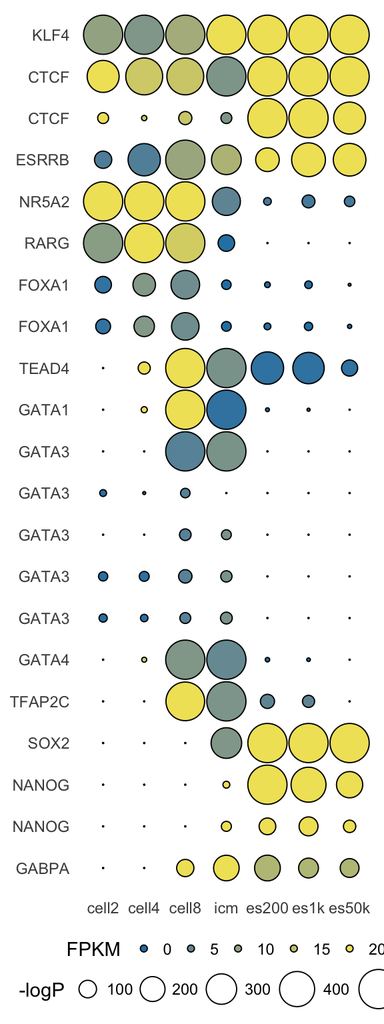

```r
##filtering with motifs in the nature paper:The landscape of accessible chromatin in mammalian preimplantation embryos
papermotif<-c("GABPA","NANOG","SOX2","POU5F1","TFAP2C","GATA4","GATA3","GATA1","TEAD4","FOXA1","RARG","NR5A2","ESRRB","CTCF","KLF4")
pmergefpkm<-merge(mergefpkm,data.frame(gene=papermotif),by="gene")
pmergefpkm<-merge(mergefpkm,data.frame(gene=papermotif,sortid=letters[1:length(papermotif)]),by="gene")
pmergefpkm<-pmergefpkm[order(pmergefpkm$sortid),]
pmergefpkm$id<-apply(pmergefpkm,1,function(x)(paste(x[18],x[9],sep="-")))
pm1<-melt(pmergefpkm[,1:9],id.var=c("id","gene"),variable.name = "type",value.name = "-logP")
pm2<-melt(pmergefpkm[,c(1,9,13:17)],id.var=c("id","gene"),variable.name = "type",value.name = "FPKM")
pm3<-rbind(pm2,pm2[pm2$type=="mESC",],pm2[pm2$type=="mESC",])
pm4<-cbind(pm1,pm3)
pm5<-pm4[,c(1:4,8)]
pm5[pm5$`-logP`>500,]$`-logP`<-500
pm5[pm5$`-logP`<10,]$`-logP`<-10
pm5[pm5$FPKM>20,]$FPKM<-20

#paper_motifs.pdf，paper的图里出现的转录因子对应的motif
p3<-ggplot(pm5,aes(type,id,size=`-logP`))+
  geom_point(shape=21,aes(fill=FPKM),position =position_dodge(0))+
  theme_minimal()+xlab(NULL)+ylab(NULL)+
  scale_size_continuous(range=c(1,15))+
  scale_fill_gradientn(colours=c("#2381B3","#F0E366"),guide="legend")+
  theme(legend.position = "bottom",legend.box = "vertical",panel.grid.major =element_blank(),legend.margin=margin(t= 0, unit='cm'),legend.spacing = unit(0,"in"))+
  scale_size_continuous(range=c(0,10))
ggsave(file="paper_motifs.pdf",height=8.4,width = 9)

#paper_gene.pdf，paper的图里出现的转录因子
ggplot(pm5,aes(type,id,size=`-logP`))+
  geom_point(shape=21,aes(fill=FPKM),position =position_dodge(0))+
  theme_minimal()+xlab(NULL)+ylab(NULL)+
  scale_size_continuous(range=c(1,15))+
  scale_fill_gradientn(colours=c("#2381B3","#F0E366"),guide="legend")+theme(legend.position = "bottom",legend.box = "vertical",panel.grid.major =element_blank(),legend.margin=margin(t= 0, unit='cm'),legend.spacing = unit(0,"in"))+
  scale_size_continuous(range=c(0,10))+scale_y_discrete(labels=pm5$gene)
```

```r
ggsave(file="paper_gene.pdf",height=8.4,width = 3.2)
```

在嘉因公众号回复“世界名画”，查看世界名画的配色代码